# A Systematic Review of the Discrimination Against individuals based on Sexual orientation in Australian society

Jiongan Wang

20/03/2022

[output not shown]

## 1.0 Executive Summary

The term “Lesbian, Gay, Bisexual, and transgender”(LGBT) is an umbrella term for persons with different sexual orientations. These individuals represent the class of sexual and gender minority individuals. Australian sexual discrimination act of the year 1984 makes it illegal and unlawful to discriminate against people based on their sexual orientation, gender identity, and intersex status. People of the LGBT community still face discrimination in many facets of life such as in public, at work, during access to public services.

The research aims to find if the people of the LGBT community are marginalized in Australian society. The research is based on key data provided by the General Social survey of 2020. This survey was conducted over four months from 15th June to 5th September 2020. This period coincided with the onset of the Covid-19 pandemic which started worldwide in the year 2020. The survey provides data on various social characteristics, general wellbeing, and varied social experiences of society in general. The survey was conducted telephonically and using online methods to around 5304 participants with a response rate of about 60%.

The findings of the study suggest that a section of individuals belonging to the LGBT community still face discrimination in some aspects of their life. They generally lack trust in the majoritarian sections of society based on sexual orientation, which is heterosexual. Experience of discrimination from recent 12 months is more in such section. Their overall trust in the policing system and healthcare access is less. This section of society has been more stressed during the last year.

The data was collected during the onset of the pandemic when there was general pessimism about various aspects of life in Australian inhabitants. The comparison with the previous year 2019 will be somewhat biased due to the lack of pandemics in the previous year. The transgender community part of an intersex group of individuals was not part of the survey as it was limited more based on sexual orientation. Above form the weakness in our study results. Overall, the questions asked in the survey resulted in giving direction to the research findings. Regular quarterly surveys will bring more insights to the study.

## 2.0 Introduction

Equality and non-discrimination are fundamental rights that should be the same for all persons clear of their sexual orientation or identity of their gender. People of minority communities such as those belonging to LGBT have been alienated in society for many generations. With more awareness on such social causes and with many governments, across the world, legalizing gay marriages the level of acceptance should have increased in society. This research aims to find if the LGBT section of society is still marginalized when compared to people with heterosexual orientation. The major aim of the research is how this section of society fares on topics such as being part of the society, safety, and security, access to public health, and general stress levels.

A general social survey (GSS) was conducted which lasted for four months from Jun till Sep-2020 and targeted several households across Australia. The survey consisted of a general questionnaire and an individual questionnaire. To ensure better response the survey respondents were given choice to compete for survey online or via telephone. Due to the prevailing pandemic, it wasn’t possible to physical follow-up and hence the non-response rate was 37%.GSS touched various aspects of participant lives with key topics such as Life satisfaction, personal stressors, trust, voluntary work, and discrimination. Based on the survey LGBT section felt less participative in community involvement are more averse to trusting people with ease. They have also faced more instances of personal threats than those of other heterosexual groups. Their stress levels are also more and get paid less than the other groups. This indicates that this section is still marginalized in the societies despite many awareness measures taken for their cause.

Limitations to the survey questions are the lack of open-ended questions which may have divulged more information. One person replied for the household which may not be representative for the entire household. There may be response bias in some individuals due to fixations of their beliefs about general society. The survey targeted economically and sociologically weaker sections of the society which may introduce some bias in the responses.

## 3.0 Data and Survey Methods

The data for the survey included the sample population of roughly 5300 Australian households. The target population is comprised of people living in Australia. People living in very remote areas of Australia were excluded from the survey. Online and telephonic interviews were primary modes for contacting the respondents. The sample population was a mix of urban and rural households. The age group for the respondents was 15 years and above. Parental consent was taken for people between the ages of 15-18.

The sample was designed in such a way that one person of the household aged 15 years and above completed the questionnaire on behalf of the household. Each household received instructions to complete the interview using online methods. Those households which were not comfortable with the online method were given the choice to complete the interview using telephonic methods.

Since inferences need to drawn for population based on sample, few steps were taken to ensure it ,which are as follows. Each person or household was initially given a number which was based on the weight of their sample representation in the population. These level weights were than calibrated to align with independent estimates of the population.The responses to the questionnaire were multiple choice with possible responses based on the Likert scale.

Some limitations may arise due to remote areas left out of the survey. People living in private dwellings, overseas visitors, On Australian defense forces and diplomates, and people from Aboriginal communities were excluded from the survey. There was a high rate of non-response by respondents (37%) which may have randomly skewed the responses through the exclusion of some segments. The prevailing pandemic may also have changed the beliefs and attitudes of people to various aspects of life. Care must be taken when comparing the results to previous surveys.

The breakup of the households responses involved in interview are as follows

#### Table: household response breakup

| Response_category | Number | Percentage |
| --- | --- | --- |
| Full responses | 5,304 | 60.5 |
| Non Response | Number | Percentage |
| Refusal | 79 | 0.9 |
| Non Response | 3,327 | 37.9 |
| Part Response | 58 | 0.7 |
| Total(Non-response) | 3,464 | 39.5 |
| Total | 8768 | 100 |

Source: Australian Bureau of Statistics, General Social Survey: Summary Results, Australia methodology 2020

## 5.0 Key Findings and Discussion

### 5.1 Results

Results are based on the survey responses received from the target sample population. The responses were analyzed to gauge if the LGBT sections feel marginalized in Australian society. The results were in sync with our hypothesis. There is a general sense of desalination in the LGBT community and they still feel not involved in various aspects of life and community in the state. They still feel discriminated against based on their sexual orientation in various walks of life. People belonging to this segment of society have experienced more discrimination of any form in the last year. They have a lesser feeling of trust in society and police and justice systems. This section has poor health standards as compared to other segments of the population. These results indicate that the government and civil society, in general, need to take steps to have an inclusive society with no discrimination based on an individual’s sexual orientation.

### 5.2 Discussion

Although concerning community involvement, the results were at par with the heterosexual group. However, there was lesser involvement of this segment of society in social groups and community support groups. The results indicated that they had lesser recent face to face interactions with family members, although they used other means of communication to cover that.

This section of society has experienced more stress in recent years. They also have difficulty in accessing the public service when compared to the population of the heterosexual group. They tend to smoke more than the other group. There is more unemployment in this section of society. About health standards, they tend to fare well among the good category of health, however, they lag in comparison to excellent health standards. Gender for this group has skewed population towards females with 61% comprising this group. Similarly, there was a younger population between the age brackets of 15-39 in this group. Their education levels are at par or better than other groups. Their income levels are better than the other group ,still they feel being a marginalized section of society. Despite gay marriages being legalized the proportion of this section comprise of lesser married people than the other group. They have lesser general trust in people, health care systems, policing, and judicial systems.

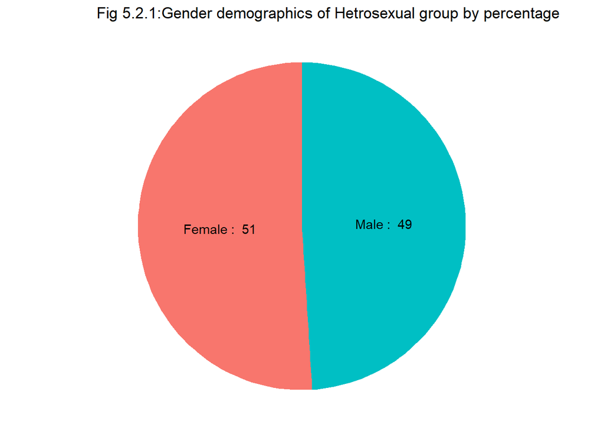

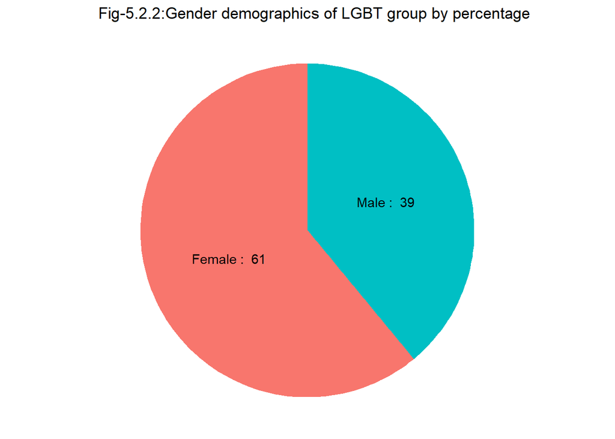

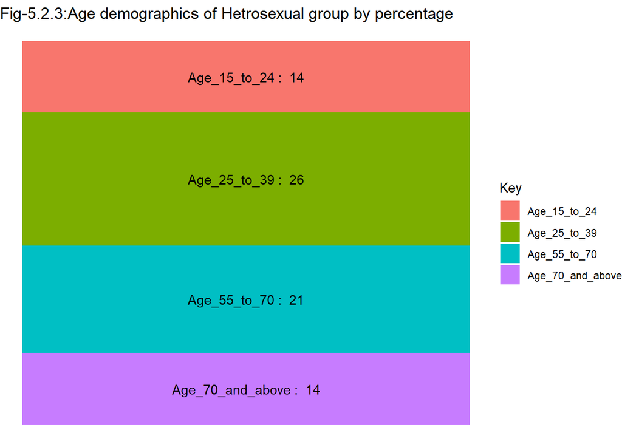

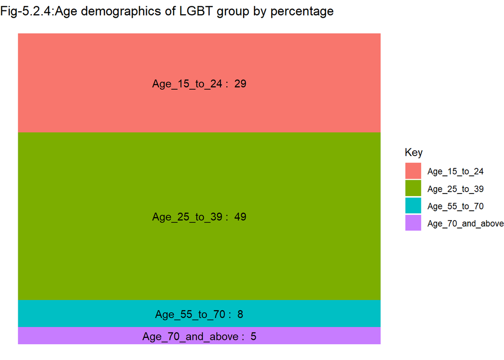

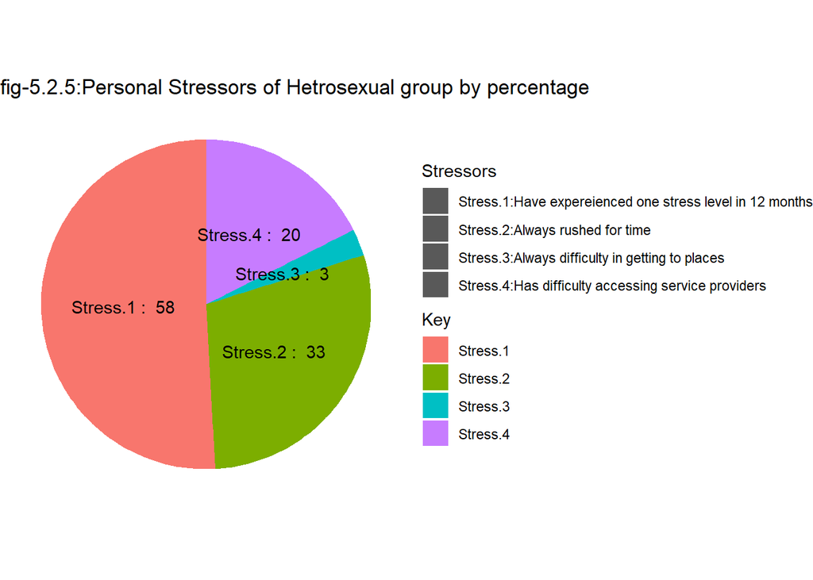

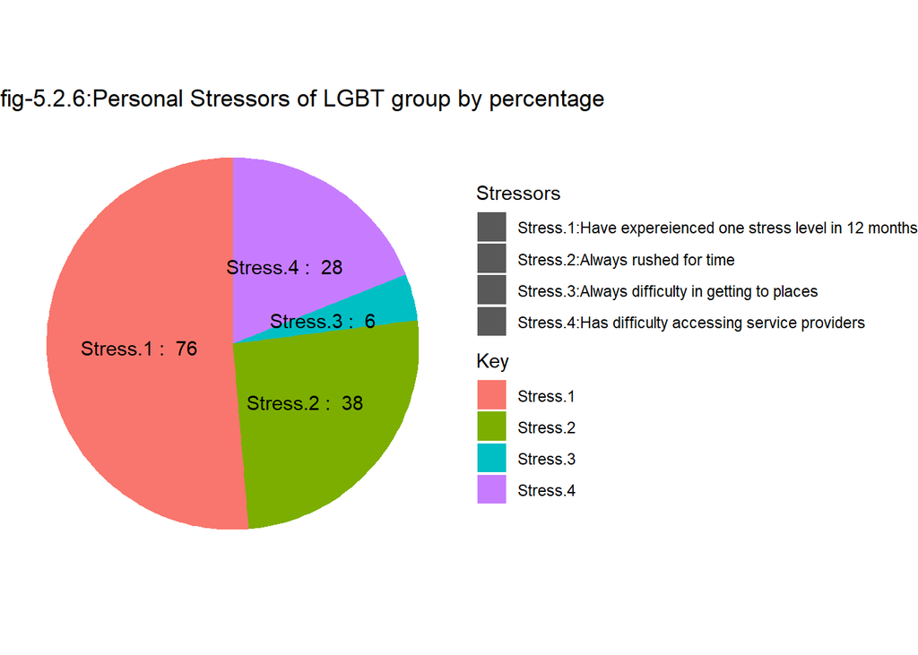

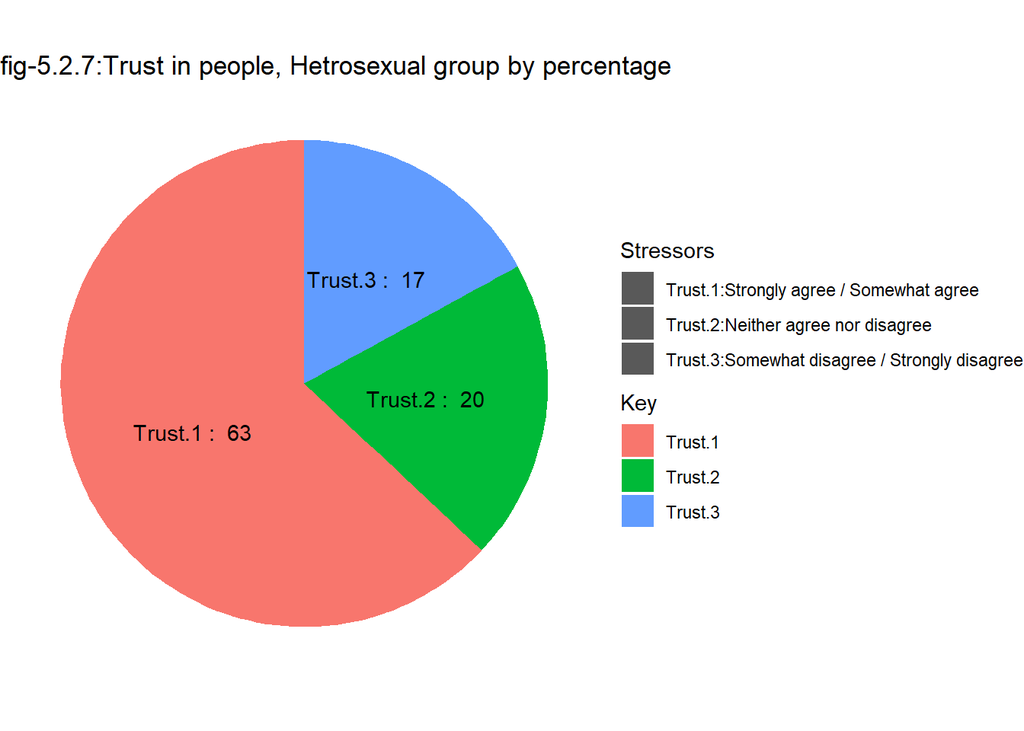

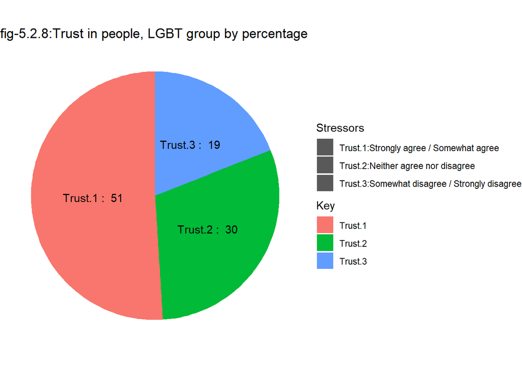

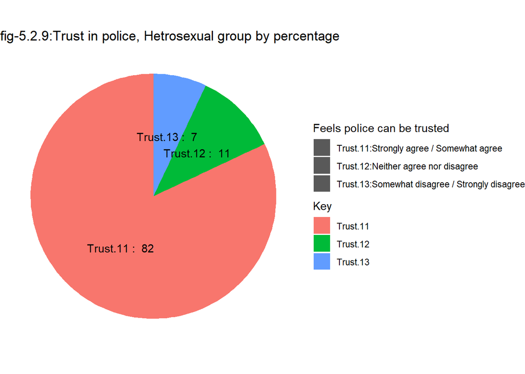

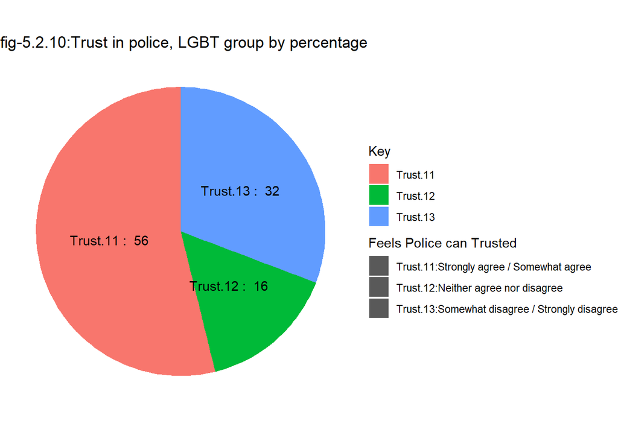

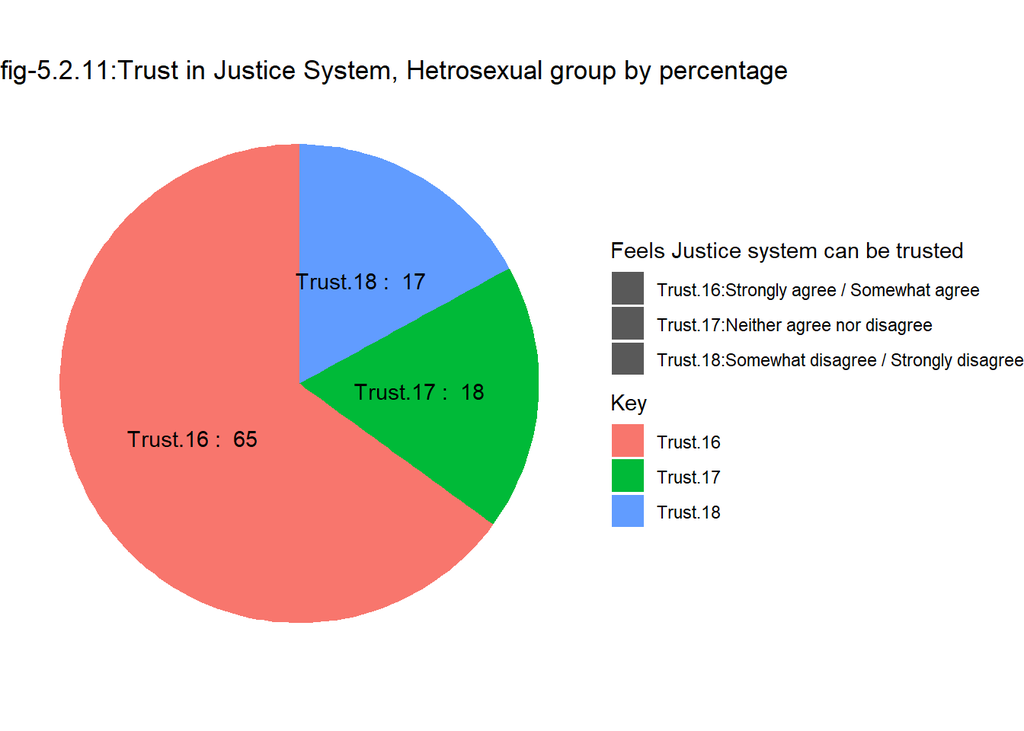

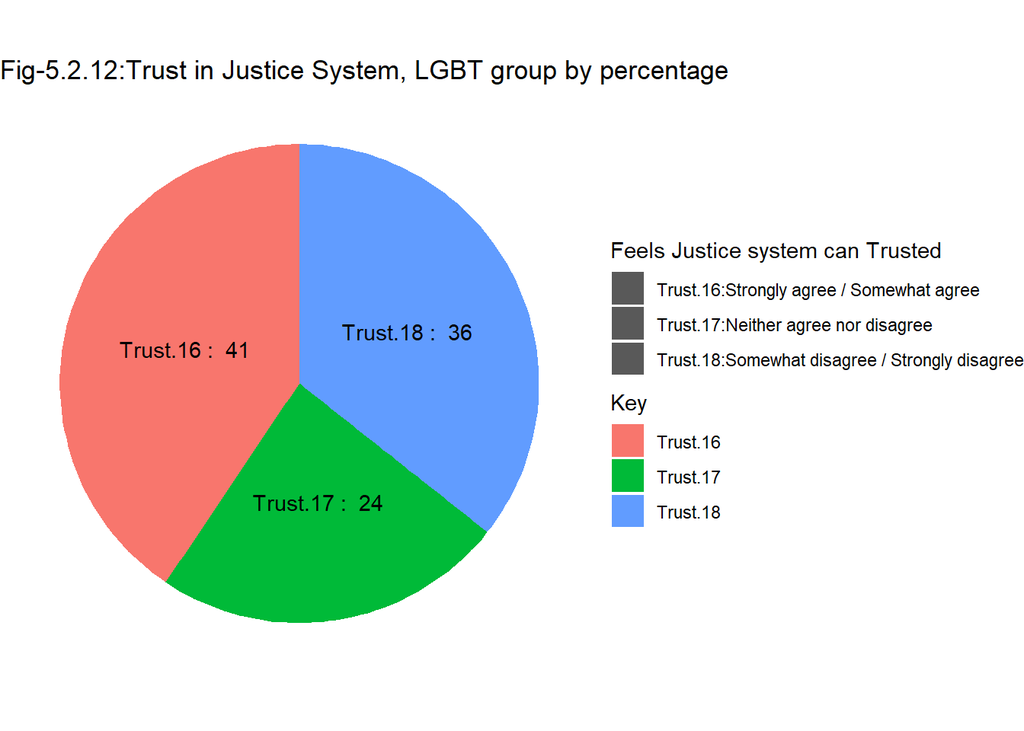

[4 more figures not shown]

### 5.3 Weakness and Limitations

The data collection period coincided with Covid Pandemic,when there was general pessimism about life aspects in whole world.Certainly Australian population would also have some impact. The comparison with the previous year 2019 will be somewhat biased due to the lack of pandemic in the previous year. The transgender community part of an inter sex group of individuals was not part of the survey as it was limited more based on sexual orientation. Above form the weakness in our study results. Overall, the questions asked in the survey resulted in giving direction to the research findings. Regular quarterly surveys will bring more insights to the study.

Lack of open ended question might be other weakness as it would encourage people to disclose more information.Mostly the economically weaker sections of the society were targeted in the survey ,which may be another source of bias.The number disparity between LGBT and heterosexual group could also bring somewhat skewness in results.Seasonal effects in the data analysis were not studied.

Further studies should overcome these limitations.

## 6.0 Appendix

Additional Questionaire to get more insight below is placed at below link

https://www.surveymonkey.com/r/5VRG3XW

glimpse of Additional Questionnaire:

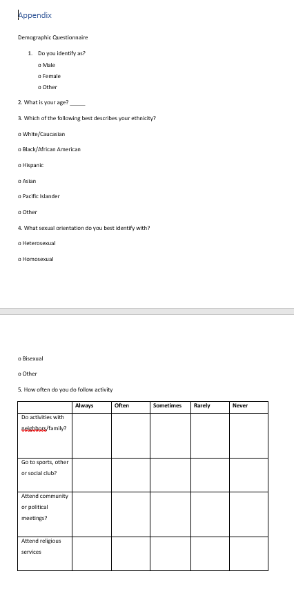

## 7.0 References

References

ABS(2021). General Social Survey: Summary Results, Australia methodology. Retrieved from https://www.abs.gov.au/methodologies/general-social-survey-summary-results-australia-methodology/2020#overview

Grünewald, M. (2011). Design and analysis of response selective samples in observational studies. La Nauze, A. (2015). Sexual orientation-based wage gaps in Australia: The potential role of discrimination and personality. The Economic and Labour Relations Review : ELRR, 26(1), 60–81. https://doi.org/10.1177/1035304615570806

Thompson, S. K. (2012). Sampling. Hoboken, N.J: Wiley.

Wickham, Hadley (2016) ggplot2: Elegant Graphics for Data Analysis. Springer-Verlag New York, 2016.